# masterlist2

## Deviation

比较少量项目（或类别）之间的数值变化与固定参考值的比较；依赖于设定的固定值，以此进行区分

### 发散性条形图（Diverging bars）

Diverging Bars是一个可以处理负值和正值的条形图。这可以通过使用geom_bar()来实现。但是geom_bar()的用法可能会很混乱。这是因为，它既可以用来制作条形图，也可以用来制作直方图。条形图的X轴为类别变量不连续，直方图的X轴为连续变量（即使可能分段）。

默认情况下，geom_bar()的统计值设置为计数。这意味着，当你只提供一个连续的X变量(没有Y变量)时，它就会试图将数据做成一个直方图。创建条形图而不是直方图，你需要;

```
设置stat=identity
在aes()中提供x和y，其中x是字符或因子，y是数值。
```

为了确保你得到的是发散的条形变量，而不是只有条形变量，请确保你的分类变量有2个类别，在连续变量的某一阈值上有2个变化。在下面的例子中，mtcars数据集中的mpg是通过计算z值来归一化的。那些mpg高于0的车辆被标记为绿色，低于0的车辆被标记为红色。

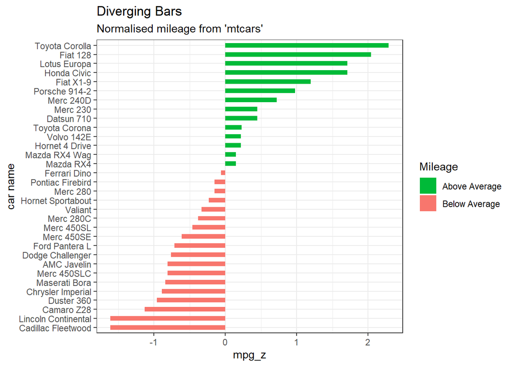

```r
library(ggplot2)
theme_set(theme_bw())

# Data Prep
data("mtcars")  # load data
mtcars$`car name` <- rownames(mtcars)
mtcars$mpg_z <- round((mtcars$mpg - mean(mtcars$mpg))/sd(mtcars$mpg), 2)  # 标准化
mtcars$mpg_type <- ifelse(mtcars$mpg_z < 0, "below", "above")
mtcars <- mtcars[order(mtcars$mpg_z), ]  # 排序
mtcars$`car name` <- factor(mtcars$`car name`, levels = mtcars$`car name`)

ggplot(mtcars, aes(x=`car name`, y=mpg_z, label=mpg_z)) +
  geom_bar(stat='identity', aes(fill=mpg_type), width=.5)  +
  scale_fill_manual(name="Mileage",
                    labels = c("Above Average", "Below Average"),
                    values = c("above"="#00ba38", "below"="#f8766d")) +
  labs(subtitle="Normalised mileage from 'mtcars'",
       title= "Diverging Bars") +
  coord_flip()
```

### Diverging Lollipop Chart

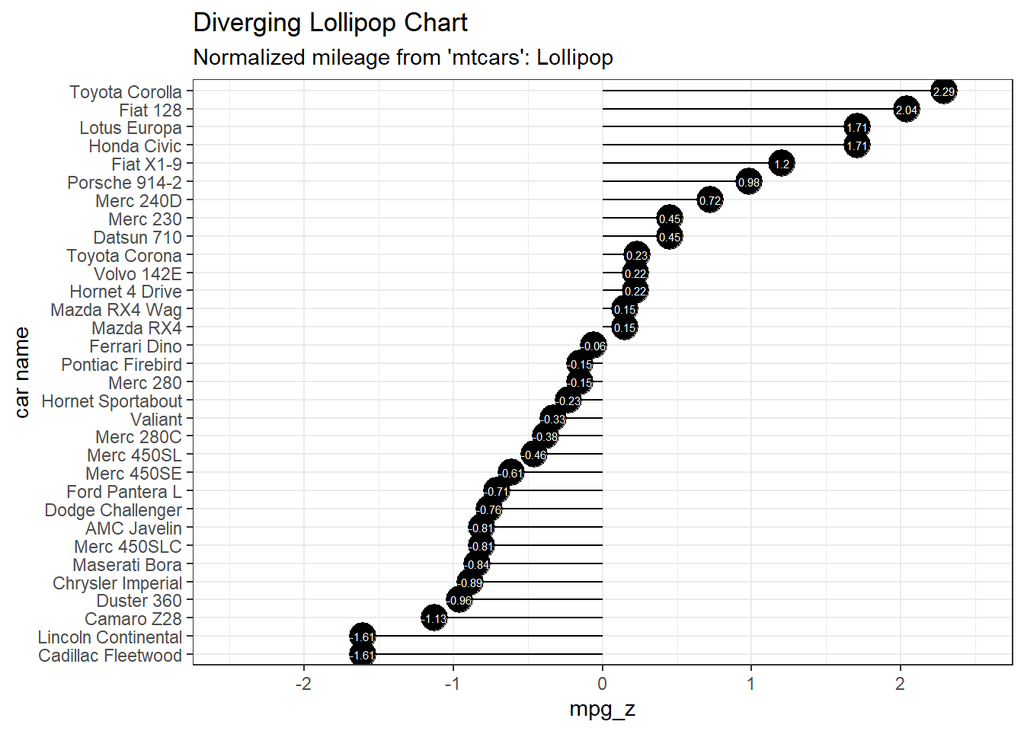

```r
library(ggplot2)
theme_set(theme_bw())

ggplot(mtcars, aes(x=`car name`, y=mpg_z, label=mpg_z)) +
  geom_point(stat='identity', fill="black", size=6)  +
  geom_segment(aes(y = 0,
                   x = `car name`,
                   yend = mpg_z,
                   xend = `car name`),
               color = "black") +
  geom_text(color="white", size=2) +
  labs(title="Diverging Lollipop Chart",
       subtitle="Normalized mileage from 'mtcars': Lollipop") +
  ylim(-2.5, 2.5) +
  coord_flip()
```

## 哑铃图

哑铃图是一个很好的工具，需要注意： 1. 可视化两个时间点之间的相对位置（如增长和下降）。 2.比较两类之间的距离。 3.为了得到正确的哑铃图的顺序，Y变量应该是一个因数，而且因数变量的级别应该和它在图中出现的顺序相同。

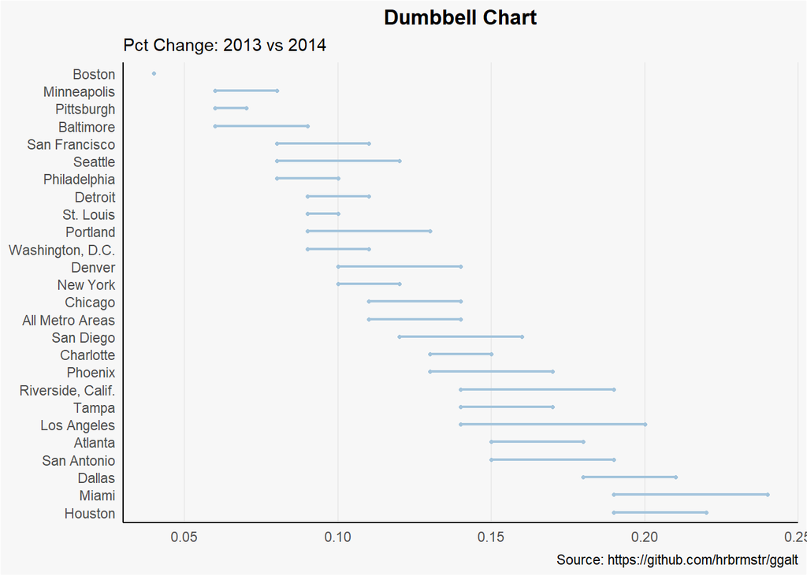

```r
library(ggplot2)
library(ggalt)
theme_set(theme_classic())

health <- read.csv("https://raw.githubusercontent.com/selva86/datasets/master/health.csv")
health$Area <- factor(health$Area, levels=as.character(health$Area))  # for right ordering of the dumbells

# health$Area <- factor(health$Area)
gg <- ggplot(health, aes(x=pct_2013, xend=pct_2014, y=Area, group=Area)) +
        geom_dumbbell(color="#a3c4dc",
                      size=0.75,
                      point.colour.l="#0e668b") +
        scale_x_continuous() +
        labs(x=NULL,
             y=NULL,
             title="Dumbbell Chart",
             subtitle="Pct Change: 2013 vs 2014",
             caption="Source: https://github.com/hrbrmstr/ggalt") +
        theme(plot.title = element_text(hjust=0.5, face="bold"),
              plot.background=element_rect(fill="#f7f7f7"),
              panel.background=element_rect(fill="#f7f7f7"),
              panel.grid.minor=element_blank(),
              panel.grid.major.y=element_blank(),
              panel.grid.major.x=element_line(),
              axis.ticks=element_blank(),
              legend.position="top",
              panel.border=element_blank())
plot(gg)
```

## 密度图

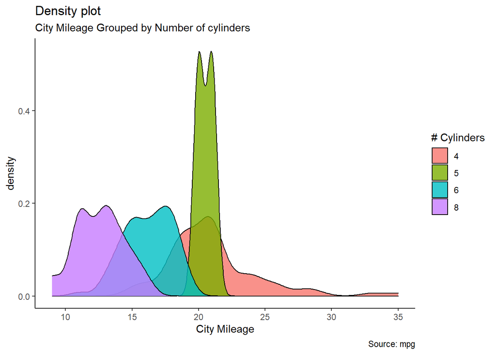

```r
library(ggplot2)
theme_set(theme_classic())

# Plot
g <- ggplot(mpg, aes(cty))
g + geom_density(aes(fill=factor(cyl)), alpha=0.8) +
    labs(title="Density plot",
         subtitle="City Mileage Grouped by Number of cylinders",
         caption="Source: mpg",
         x="City Mileage",
         fill="# Cylinders")
```

## 箱状图

箱状图是研究分布的一个很好的工具。它还可以显示多组内的分布，以及中位数、范围和离群值（如果有的话）。

框内的暗线代表中位数。框的顶部是75%点，框的底部是25%点。线的端点的距离为1.5*IQR，其中IQR或四分位数区间范围（Inter Quartile Range）是指第25和75百分位数之间的距离。在线须之外的点被标记为点，通常被认为是异常值点。

设置varwidth=T可以调整方框的宽度，使其宽度与所包含的观察数成正比。

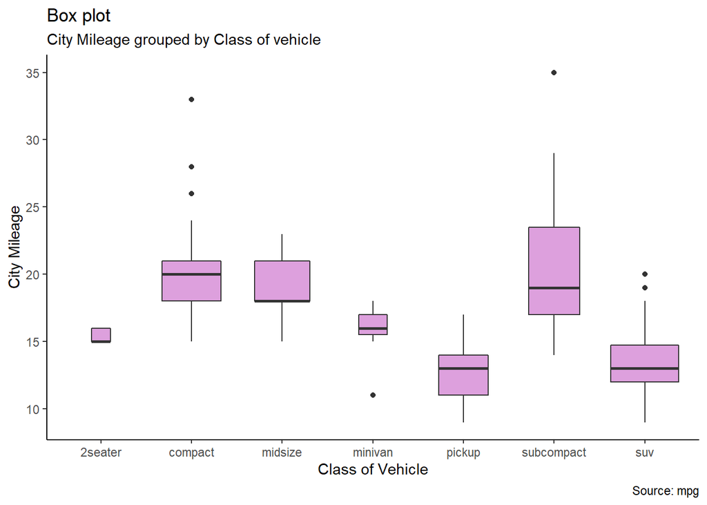

```r
library(ggplot2)
theme_set(theme_classic())

# Plot
g <- ggplot(mpg, aes(class, cty))
g + geom_boxplot(varwidth=T, fill="plum") +
    labs(title="Box plot",
         subtitle="City Mileage grouped by Class of vehicle",
         caption="Source: mpg",
         x="Class of Vehicle",
         y="City Mileage")
```

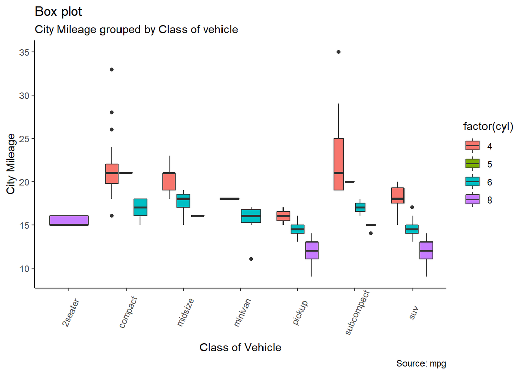

```r
library(ggthemes)
g <- ggplot(mpg, aes(class, cty))
g + geom_boxplot(aes(fill=factor(cyl))) + #按cyl填充颜色
  theme(axis.text.x = element_text(angle=65, vjust=0.6)) +
  labs(title="Box plot",
       subtitle="City Mileage grouped by Class of vehicle",
       caption="Source: mpg",
       x="Class of Vehicle",
       y="City Mileage")
```

## 小提琴图

小提琴图类似于箱状图，但显示的是组内的密度。没有像boxplots那样提供很多信息（分位数）。可以用geom_violin()来绘制。

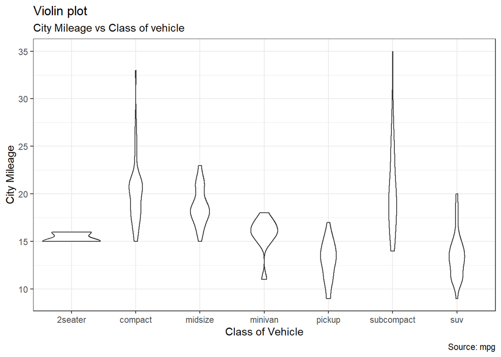

```r
library(ggplot2)
theme_set(theme_bw())

# plot
g <- ggplot(mpg, aes(class, cty))
g + geom_violin() +
  labs(title="Violin plot",
       subtitle="City Mileage vs Class of vehicle",
       caption="Source: mpg",
       x="Class of Vehicle",
       y="City Mileage")
```

## 构成图

### 华夫饼图

华夫饼图是一个很好的显示总人口分类构成的方法。虽然没有直接的函数，但可以通过使用geom_tile()函数巧妙地操纵gggplot2来表达。下面的模板应该可以帮助你创建自己的华夫饼。

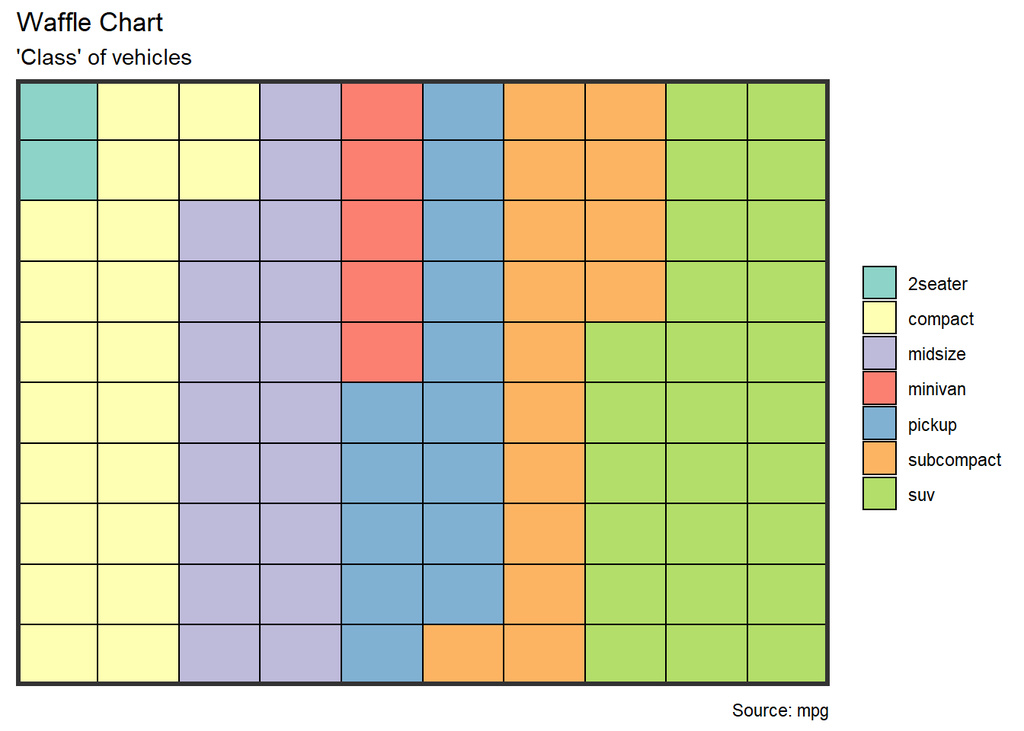

```r
var <- mpg$class

nrows <- 10
df <- expand.grid(y = 1:nrows, x = 1:nrows)
categ_table <- round(table(var) * ((nrows*nrows)/(length(var))))

df$category <- factor(rep(names(categ_table), categ_table))
# NOTE: if sum(categ_table) is not 100 (i.e. nrows^2), it will need adjustment to make the sum to 100.

## Plot
ggplot(df, aes(x = x, y = y, fill = category)) +
        geom_tile(color = "black", size = 0.5) +
        scale_x_continuous(expand = c(0, 0)) +
        scale_y_continuous(expand = c(0, 0), trans = 'reverse') +
        scale_fill_brewer(palette = "Set3") +
        labs(title="Waffle Chart", subtitle="'Class' of vehicles",
             caption="Source: mpg") +
        theme(panel.border = element_rect(size = 2),
              plot.title = element_text(size = rel(1.2)),
              axis.text = element_blank(),
              axis.title = element_blank(),
              axis.ticks = element_blank(),
              legend.title = element_blank(),
              legend.position = "right")
```

现在可以直接利用waffle函数包进行创建,下边是一个基础图形，更多可见https://github.com/hrbrmstr/waffle

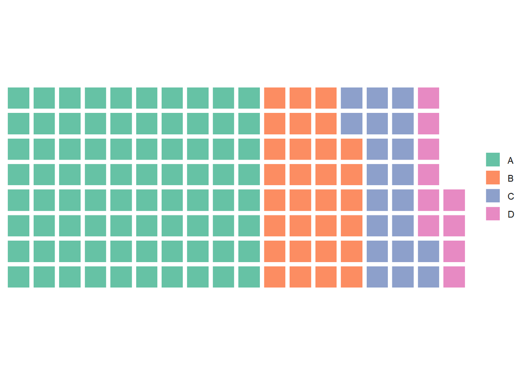

```r
library(waffle)
parts <- data.frame(
  names = LETTERS[1:4],
  vals = c(80, 30, 20, 10)
)

waffle(parts, rows = 8)
```

## 树形图

为了创建一个treemap，必须使用treemapify()将数据转换为所需的格式。重要的要求是，你的数据必须有一个变量，每个变量必须有一个描述瓷砖面积的变量、填充颜色的变量、有瓷砖标签的变量，最后是父组。

数据格式化完成后，只需在treemapify数据上调用gggplotify()即可。

```r
library(treemap)

# Build Dataset
group <- c(rep("group-1",4),rep("group-2",2),rep("group-3",3))
subgroup <- paste("subgroup" , c(1,2,3,4,1,2,1,2,3), sep="-")
value <- c(13,5,22,12,11,7,3,1,23)
data <- data.frame(group,subgroup,value)
print(data)
```

```
##     group   subgroup value
## 1 group-1 subgroup-1    13
## 2 group-1 subgroup-2     5
## 3 group-1 subgroup-3    22
## 4 group-1 subgroup-4    12
## 5 group-2 subgroup-1    11
## 6 group-2 subgroup-2     7
## 7 group-3 subgroup-1     3
## 8 group-3 subgroup-2     1
## 9 group-3 subgroup-3    23
```

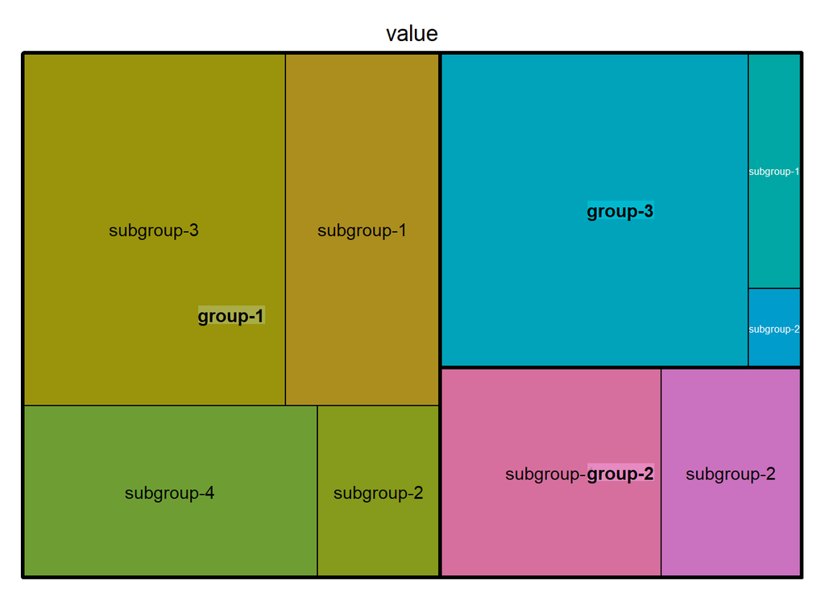

```r
# treemap
treemap(data,
            index=c("group","subgroup"),
            vSize="value",
            type="index"
            )
```

## 聚类图

可以使用geom_encircle()来显示不同的聚类或组。如果数据集有多个弱特征，可以计算出主成分，并使用PC1和PC2作为X轴和Y轴绘制散点图。

可以使用geom_encircle()来包围所需的组。唯一需要注意的是geom_circle()的数据参数。你需要提供一个子集数据框，其中只包含属于该组的观测值（行）作为数据参数。

```r
library(ggplot2)
library(ggalt)
library(ggfortify)
theme_set(theme_classic())

# Compute data with principal components ------------------
df <- iris[c(1, 2, 3, 4)]
pca_mod <- prcomp(df)  # compute principal components

# Data frame of principal components ----------------------
df_pc <- data.frame(pca_mod$x, Species=iris$Species)  # dataframe of principal components
df_pc_vir <- df_pc[df_pc$Species == "virginica", ]  # df for 'virginica'
df_pc_set <- df_pc[df_pc$Species == "setosa", ]  # df for 'setosa'
df_pc_ver <- df_pc[df_pc$Species == "versicolor", ]  # df for 'versicolor'
summary(df_pc)
```

```
##       PC1               PC2                PC3                PC4
##  Min.   :-3.2238   Min.   :-1.37417   Min.   :-0.76017   Min.   :-0.5054344
##  1st Qu.:-2.5303   1st Qu.:-0.32492   1st Qu.:-0.17582   1st Qu.:-0.0778999
##  Median : 0.5546   Median : 0.02216   Median :-0.01639   Median : 0.0007274
##  Mean   : 0.0000   Mean   : 0.00000   Mean   : 0.00000   Mean   : 0.0000000
##  3rd Qu.: 1.5501   3rd Qu.: 0.32542   3rd Qu.: 0.20550   3rd Qu.: 0.0896801
##  Max.   : 3.7956   Max.   : 1.26597   Max.   : 0.69415   Max.   : 0.5053050
##        Species
##  setosa    :50
##  versicolor:50
##  virginica :50
##
##
##
```

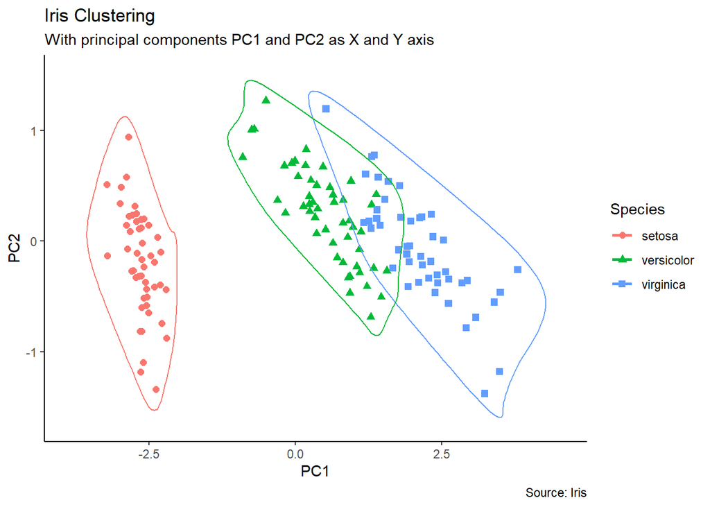

```r
# Plot ----------------------------------------------------
ggplot(df_pc, aes(PC1, PC2, col=Species)) +
  geom_point(aes(shape=Species), size=2) +   # draw points
  labs(title="Iris Clustering",
       subtitle="With principal components PC1 and PC2 as X and Y axis",
       caption="Source: Iris") +
  coord_cartesian(xlim = 1.2 * c(min(df_pc$PC1), max(df_pc$PC1)),
                  ylim = 1.2 * c(min(df_pc$PC2), max(df_pc$PC2))) +   # change axis limits
  geom_encircle(data = df_pc_vir, aes(x=PC1, y=PC2)) +   # draw circles
  geom_encircle(data = df_pc_set, aes(x=PC1, y=PC2)) +
  geom_encircle(data = df_pc_ver, aes(x=PC1, y=PC2))
```